# Multicollinearity

## Key concepts

- Transformations
- Multicollinearity

## LA Homes

[figure not shown]

What factors help explain the price of a home in Los Angeles?

## Model building

We'd like to build a model to explain prices of homes in LA as a function of the characteristics of those homes.

\[ \widehat{price} = location + size + pool + acreage \ldots \]

1. Statistical question
2. Data wrangling
3. Exploratory Data Analysis
4. Modeling
5. Interpretation

Recall: *exploratory* vs. *confirmatory* analysis.

## Data Wrangling

## Data wrangling

Home price data is available on many websites now, including zillow.com.

```r
LA <- read.csv("http://andrewpbray.github.io/data/LA.csv")
head(LA)
```

```
##         city type bed bath garage sqft pool spa  price
## 1 Long Beach        0    1         513       NA 119000
## 2 Long Beach        0    1         550       NA 153000
## 3 Long Beach        0    1         550       NA 205000
## 4 Long Beach        0    1      1 1030       NA 300000
## 5 Long Beach        0    1      1 1526       NA 375000
## 6 Long Beach        1    1         552       NA 159900
```

**Unit of observation**: a home for sale in west LA.  
**Population**: all homes in west LA.

```r
str(LA)
```

```
## 'data.frame':    1594 obs. of  9 variables:
##  $ city  : Factor w/ 4 levels "Beverly Hills",..: 2 2 2 2 2 2 2 2 2 2 ...
##  $ type  : Factor w/ 3 levels "","Condo/Twh",..: 1 1 1 1 1 1 1 1 1 1 ...
##  $ bed   : int  0 0 0 0 0 1 1 1 1 1 ...
##  $ bath  : num  1 1 1 1 1 1 1 1 1 1 ...
##  $ garage: Factor w/ 5 levels "","1","2","3",..: 1 1 1 2 2 1 1 1 1 1 ...
##  $ sqft  : int  513 550 550 1030 1526 552 558 596 744 750 ...
##  $ pool  : Factor w/ 2 levels "","Y": 1 1 1 1 1 1 1 1 1 1 ...
##  $ spa   : logi  NA NA NA NA NA NA ...
##  $ price : num  119000 153000 205000 300000 375000 ...
```

```r
levels(LA$city)
```

```
## [1] "Beverly Hills" "Long Beach"    "Santa Monica"  "Westwood"
```

### Recoding `type`

The levels of a categorical variable can be queried and reset using `levels()`.

```r
levels(LA$type)
```

```
## [1] ""          "Condo/Twh" "SFR"
```

```r
levels(LA$type) <- c("unknown", "condo", "sfr")
levels(LA$type)
```

```
## [1] "unknown" "condo"   "sfr"
```

### Recoding `garage`

```r
str(LA)
```

```
## 'data.frame':    1594 obs. of  9 variables:
##  $ city  : Factor w/ 4 levels "Beverly Hills",..: 2 2 2 2 2 2 2 2 2 2 ...
##  $ type  : Factor w/ 3 levels "unknown","condo",..: 1 1 1 1 1 1 1 1 1 1 ...
##  $ bed   : int  0 0 0 0 0 1 1 1 1 1 ...
##  $ bath  : num  1 1 1 1 1 1 1 1 1 1 ...
##  $ garage: Factor w/ 5 levels "","1","2","3",..: 1 1 1 2 2 1 1 1 1 1 ...
##  $ sqft  : int  513 550 550 1030 1526 552 558 596 744 750 ...
##  $ pool  : Factor w/ 2 levels "","Y": 1 1 1 1 1 1 1 1 1 1 ...
##  $ spa   : logi  NA NA NA NA NA NA ...
##  $ price : num  119000 153000 205000 300000 375000 ...
```

What's going on with garage?

### Recoding `garage`

```r
levels(LA$garage)
```

```
## [1] ""   "1"  "2"  "3"  "4+"
```

```r
table(LA$garage)
```

```
##
##       1   2   3  4+
## 388 260 666  37   6
```

We can combine levels using a similar approach.

```r
levels(LA$garage) <- c("small", "small", "large", "large", "large")
table(LA$garage)
```

```
##
## small large
##   648   709
```

```r
str(LA)
```

```
## 'data.frame':    1594 obs. of  9 variables:
##  $ city  : Factor w/ 4 levels "Beverly Hills",..: 2 2 2 2 2 2 2 2 2 2 ...
##  $ type  : Factor w/ 3 levels "unknown","condo",..: 1 1 1 1 1 1 1 1 1 1 ...
##  $ bed   : int  0 0 0 0 0 1 1 1 1 1 ...
##  $ bath  : num  1 1 1 1 1 1 1 1 1 1 ...
##  $ garage: Factor w/ 2 levels "small","large": 1 1 1 1 1 1 1 1 1 1 ...
##  $ sqft  : int  513 550 550 1030 1526 552 558 596 744 750 ...
##  $ pool  : Factor w/ 2 levels "","Y": 1 1 1 1 1 1 1 1 1 1 ...
##  $ spa   : logi  NA NA NA NA NA NA ...
##  $ price : num  119000 153000 205000 300000 375000 ...
```

What's going on with `pool` and `spa`?

### Dropping columns

```r
table(LA$pool)
```

```
##
##         Y
## 1448  146
```

```r
sum(is.na(LA$spa))
```

```
## [1] 1594
```

Two variables seem mis-coded/uninformative, so they should be dropped.

```r
LA <- select(LA, -pool, -spa)
```

## Fully wrangled data set

```r
head(LA)
```

```
##         city    type bed bath garage sqft  price
## 1 Long Beach unknown   0    1  small  513 119000
## 2 Long Beach unknown   0    1  small  550 153000
## 3 Long Beach unknown   0    1  small  550 205000
## 4 Long Beach unknown   0    1  small 1030 300000
## 5 Long Beach unknown   0    1  small 1526 375000
## 6 Long Beach unknown   1    1  small  552 159900
```

Once the data set is ready to go, save it to a new .csv file.

```r
write.csv(LA, file = "LA.csv")
```

## Exploratory Data Analysis

## EDA

Our goals are to

1. Develop a sense of the *univariate* distributions in terms of center, shape, spread, unusual observations.
2. Develop a sense of the *bivariate* and *multivariate* distributions and what they indicate about the relationship between variables.

## Question

Which of the following at *not* good methods to visualize the distribution of a single variable?

1. mosaic plot
2. density plot
3. scatterplot
4. histogram
5. side-by-side boxplots

## Question

Which of the following at *not* good methods to visualize the distribution of a single variable?

1. **mosaic plot**
2. density plot
3. **scatterplot**
4. histogram
5. **side-by-side boxplots**

## EDA for `price`

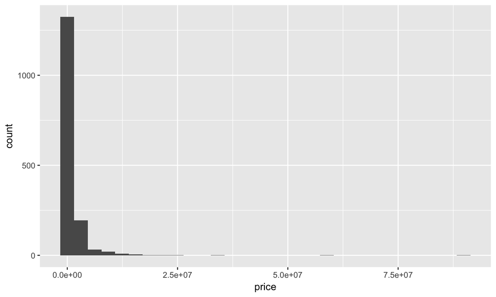

```r
qplot(x = price, data = LA, geom = "histogram")
```

## Question

How would you visualize the relationship between `price` and `city`?

```r
head(LA)
```

```
##         city    type bed bath garage sqft  price
## 1 Long Beach unknown   0    1  small  513 119000
## 2 Long Beach unknown   0    1  small  550 153000
## 3 Long Beach unknown   0    1  small  550 205000
## 4 Long Beach unknown   0    1  small 1030 300000
## 5 Long Beach unknown   0    1  small 1526 375000
## 6 Long Beach unknown   1    1  small  552 159900
```

How would you visualize the relationship between `price` and `city`?

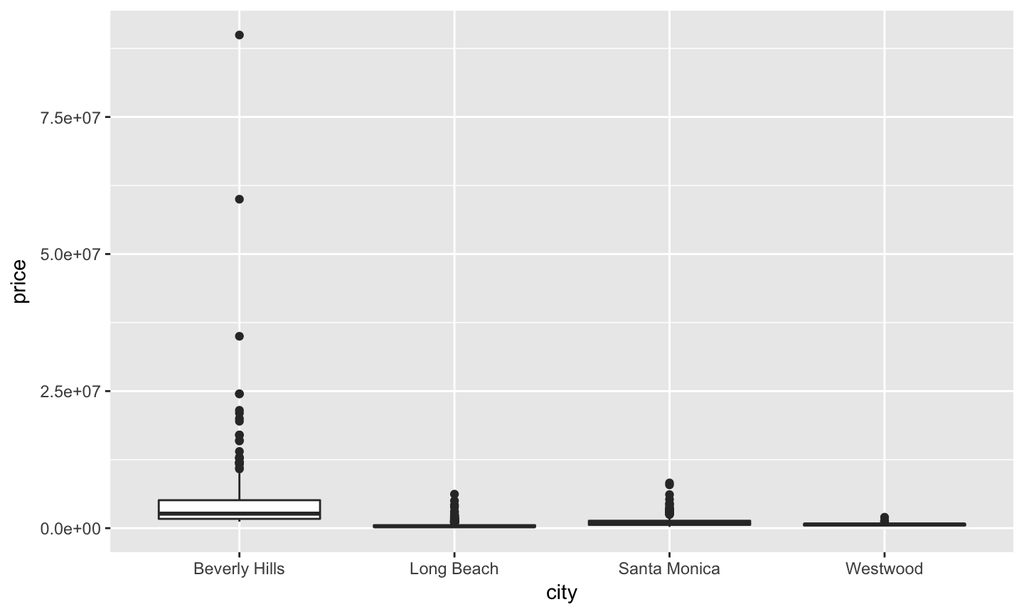

```r
qplot(x = city, y = price, data = LA, geom = "boxplot")
```

## Question

How would you visualize the relationship between `price` and `sqft`?

```r
head(LA)
```

```
##         city    type bed bath garage sqft  price
## 1 Long Beach unknown   0    1  small  513 119000
## 2 Long Beach unknown   0    1  small  550 153000
## 3 Long Beach unknown   0    1  small  550 205000
## 4 Long Beach unknown   0    1  small 1030 300000
## 5 Long Beach unknown   0    1  small 1526 375000
## 6 Long Beach unknown   1    1  small  552 159900
```

How would you visualize the relationship between `price` and `sqft`?

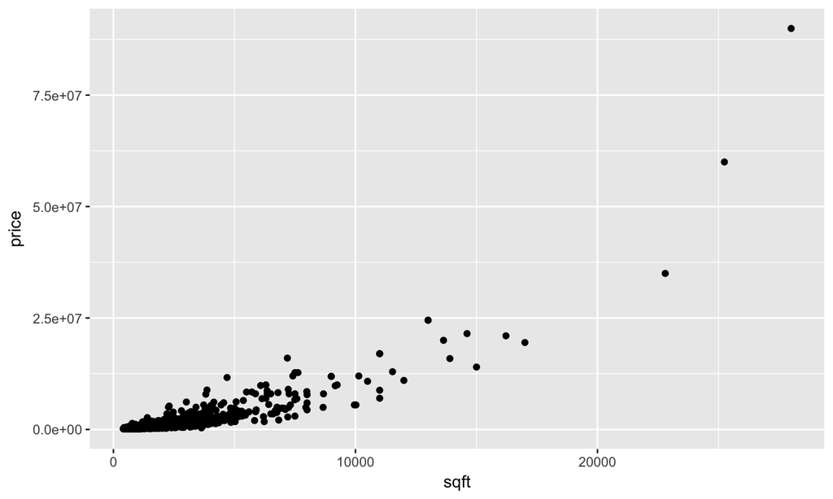

```r
qplot(x = sqft, y = price, data = LA, geom = "point")
```

## Transformations

Highly skewed data (particularly the response) can be very difficult to model using least squares regression. A common solution is to consider a transformation of the variable.

\[ \widehat{price} \sim sqft \]

versus

\[\widehat{log(price)} \sim log(sqft) \]

```r
m1 <- lm(price ~ sqft, data = LA)
m2 <- lm(log(price) ~ log(sqft), data = LA)
```

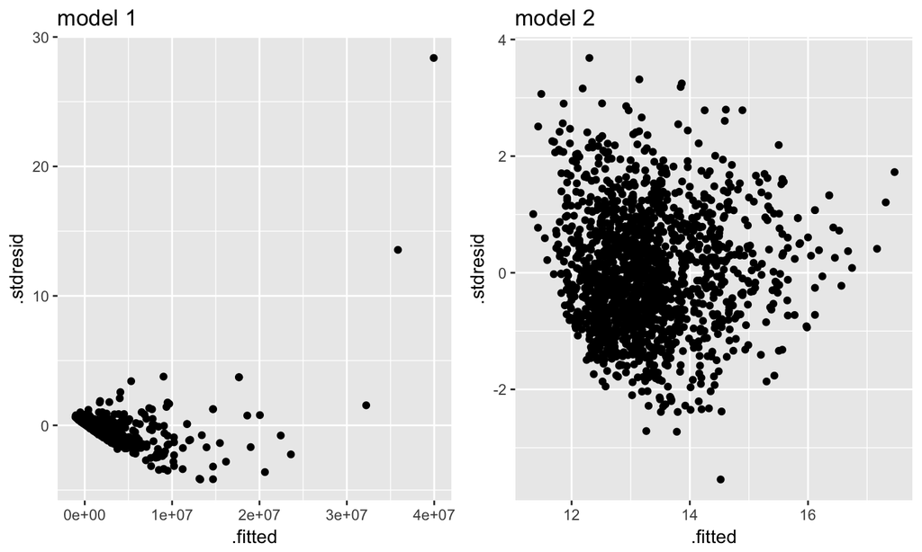

## Transformation

Highly skewed data often leads to invalid models. This can be often be fixed with a transformation, but the interpretations change slightly.

```
##             Estimate Std. Error t value Pr(>|t|)
## (Intercept)     2.70     0.1437    18.8 1.97e-71
## log(sqft)       1.44     0.0195    73.8 0.00e+00
```

*A one unit increase in the log sqft of a home is associated with a 1.44 unit increase in the log price of a home.*

## Modeling

## A simple model for price

\[ \widehat{log(price)} \sim bed \]

```r
m3 <- lm(log(price) ~ bed, data = LA)
```

What do you expect the *sign* of the slope for `bed` to be?

```r
summary(m3)$coef
```

```
##             Estimate Std. Error t value  Pr(>|t|)
## (Intercept)   11.802     0.0436   270.6  0.00e+00
## bed            0.532     0.0142    37.3 9.77e-220
```

## A less simple model for price

\[ \widehat{log(price)} \sim bed + log(sqft) \]

```r
m4 <- lm(log(price) ~ bed + log(sqft), data = LA)
```

What do you expect the *sign* of the slope for `bed` and `sqft` to be?

```r
summary(m4)$coef
```

```
##             Estimate Std. Error t value  Pr(>|t|)
## (Intercept)    1.467     0.2178    6.73  2.28e-11
## bed           -0.123     0.0164   -7.46  1.46e-13
## log(sqft)      1.656     0.0346   47.85 2.60e-310
```

## Multicollinearity

Correlation between the predictors has some important consequences:

1. Addition or removal of correlated predictors can lead to slope sign changes.
2. Correlation between the predictors leads to an inflated \(SE(b_1)\).

In sum: multicollinearity leads to **instability** in your estimates.

## The SE of the slope

In the case of a MLR model with two correlated predictors,

\[ Y = \beta_0 + \beta_1 X_1 + \beta_2 X_2 + \epsilon \]

If \(r_{1,2}\) is the correlation between \(X_1\) and \(X_2\), then.

\[SE(b_i) \propto \frac{\sigma}{1 - r_{1,2}}\]

## Multicollinearity

**Take-home lesson**: if your predictors are correlated, then they're carrying the same information about the response and your model with have a difficult time attributing explanatory power to this variable or that.

One solution: remove one/some of the correlated predictors.